# MATH 9102 - Probability and Statistical Inference Assignment - 4

Antonio Silva (D23129331@mytudublin.ie)

```
##  Hlavac, Marek (2022). stargazer: Well-Formatted Regression and Summary Statistics Tables.
```

```
##  R package version 5.2.3. https://CRAN.R-project.org/package=stargazer
```

# Question 1 - Linear regression with dummy variable [5 marks]

Consider the dataset “weatherhistory.csv”.

1. Describe dependent variable pressure and independent variable temperature.
2. Explore the relationship between pressure and temperature.
3. Build a linear model considering temperature and pressure.
4. Identify a dummy variable and build extended model considering dummy variable.
5. Report your findings.

## Answer

### a) Describe dependent variable pressure and independent variable temperature.

Load the dataset

```r
weatherHistory <- read.csv("weatherHistory.csv")
str(weatherHistory)
```

```
## 'data.frame':    96452 obs. of  13 variables:
##  $ X                  : int  2 3 4 5 6 7 8 9 10 11 ...
##  $ time               : chr  "2006-04-01 01:00:00.000 +0200" "2006-04-01 02:00:00.000 +0200" "2006-04-01 03:00:00.000 +0200" "2006-04-01 04:00:00.000 +0200" ...
##  $ summary            : chr  "Partly Cloudy" "Mostly Cloudy" "Partly Cloudy" "Mostly Cloudy" ...
##  $ precipType         : chr  "rain" "rain" "rain" "rain" ...
##  $ temperature        : num  9.36 9.38 8.29 8.76 9.22 ...
##  $ apparentTemperature: num  7.23 9.38 5.94 6.98 7.11 ...
##  $ humidity           : num  0.86 0.89 0.83 0.83 0.85 0.95 0.89 0.82 0.72 0.67 ...
##  $ windSpeed          : num  14.26 3.93 14.1 11.04 13.96 ...
##  $ windBearing        : int  259 204 269 259 258 259 260 259 279 290 ...
##  $ visibility         : num  15.8 15 15.8 15.8 15 ...
##  $ loudCover          : int  0 0 0 0 0 0 0 0 0 0 ...
##  $ pressure           : num  1016 1016 1016 1017 1017 ...
##  $ dailySummary       : chr  "Partly cloudy throughout the day." "Partly cloudy throughout the day." "Partly cloudy throughout the day." "Partly cloudy throughout the day." ...
```

```r
head(weatherHistory)
```

```
##   X                          time       summary precipType temperature
## 1 2 2006-04-01 01:00:00.000 +0200 Partly Cloudy       rain    9.355556
## 2 3 2006-04-01 02:00:00.000 +0200 Mostly Cloudy       rain    9.377778
## 3 4 2006-04-01 03:00:00.000 +0200 Partly Cloudy       rain    8.288889
## 4 5 2006-04-01 04:00:00.000 +0200 Mostly Cloudy       rain    8.755556
## 5 6 2006-04-01 05:00:00.000 +0200 Partly Cloudy       rain    9.222222
## 6 7 2006-04-01 06:00:00.000 +0200 Partly Cloudy       rain    7.733333
##   apparentTemperature humidity windSpeed windBearing visibility loudCover
## 1            7.227778     0.86   14.2646         259    15.8263         0
## 2            9.377778     0.89    3.9284         204    14.9569         0
## 3            5.944444     0.83   14.1036         269    15.8263         0
## 4            6.977778     0.83   11.0446         259    15.8263         0
## 5            7.111111     0.85   13.9587         258    14.9569         0
## 6            5.522222     0.95   12.3648         259     9.9820         0
##   pressure                      dailySummary
## 1  1015.63 Partly cloudy throughout the day.
## 2  1015.94 Partly cloudy throughout the day.
## 3  1016.41 Partly cloudy throughout the day.
## 4  1016.51 Partly cloudy throughout the day.
## 5  1016.66 Partly cloudy throughout the day.
## 6  1016.72 Partly cloudy throughout the day.
```

```r
colnames(weatherHistory)
```

```
##  [1] "X"                   "time"                "summary"
##  [4] "precipType"          "temperature"         "apparentTemperature"
##  [7] "humidity"            "windSpeed"           "windBearing"
## [10] "visibility"          "loudCover"           "pressure"
## [13] "dailySummary"
```

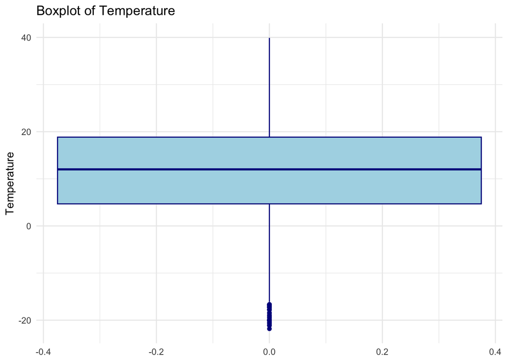

```r
ggplot(weatherHistory, aes(y = temperature)) +
  geom_boxplot(fill = "lightblue", colour = "darkblue") +
  labs(title = "Boxplot of Temperature", y = "Temperature") +
  theme_minimal()
```

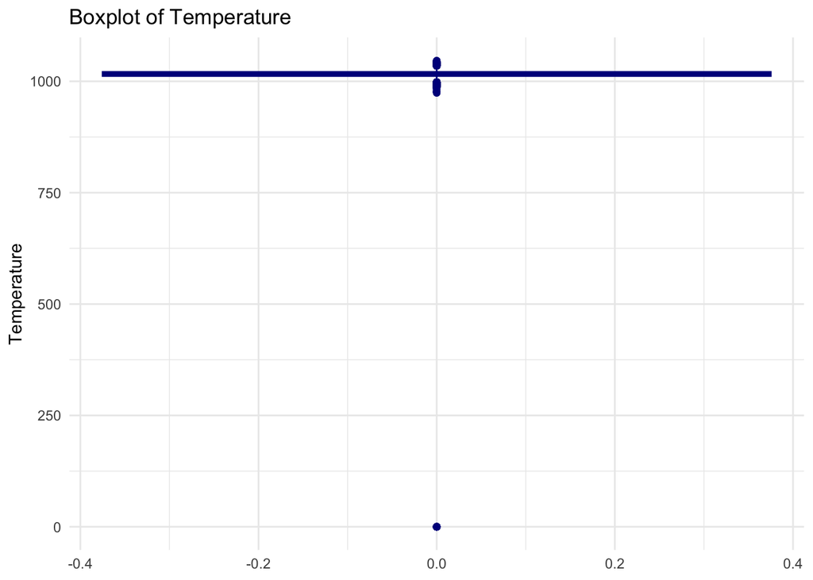

```r
ggplot(weatherHistory, aes(y = pressure)) +
  geom_boxplot(fill = "lightblue", colour = "darkblue") +
  labs(title = "Boxplot of Temperature", y = "Temperature") +
  theme_minimal()
```

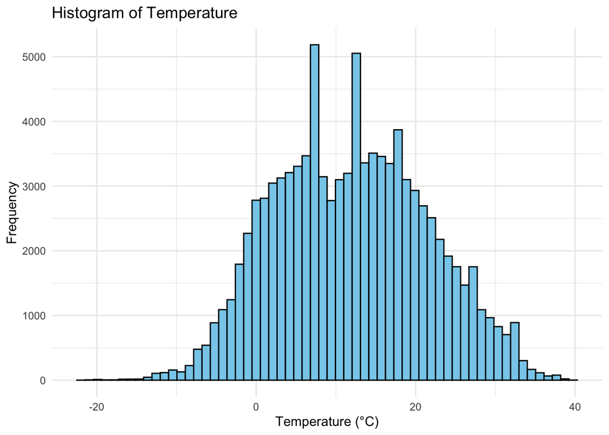

```r
ggplot(weatherHistory, aes(x = temperature)) +
  geom_histogram(bins = 60, fill = "skyblue", color = "black") + # You can adjust the number of bins
  labs(title = "Histogram of Temperature", x = "Temperature (°C)", y = "Frequency") +
  theme_minimal()
```

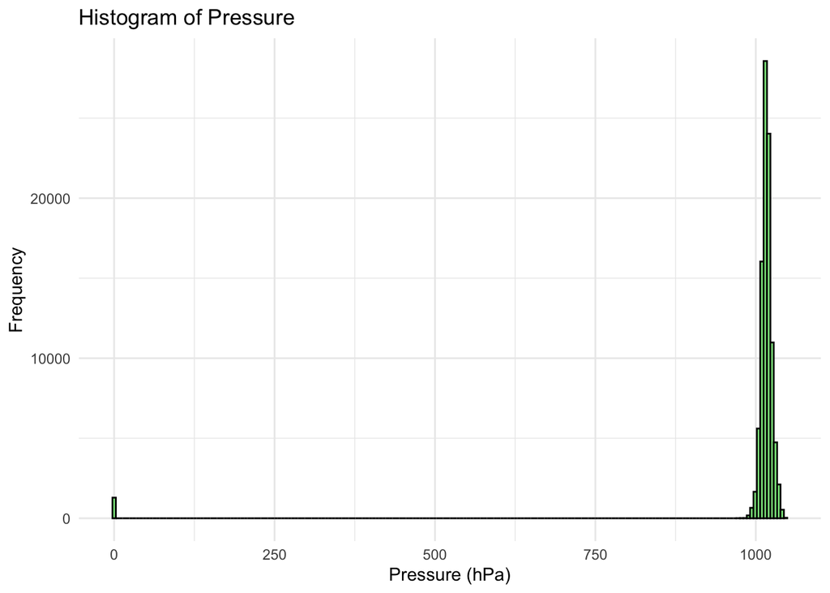

```r
ggplot(weatherHistory, aes(x = pressure)) +
  geom_histogram(bins = 200, fill = "lightgreen", color = "black") + # Adjust the number of bins as needed
  labs(title = "Histogram of Pressure", x = "Pressure (hPa)", y = "Frequency") +
  theme_minimal()
```

```r
psych::describe(weatherHistory[, c("temperature", "pressure")])
```

```
##             vars     n    mean     sd  median trimmed   mad    min     max
## temperature    1 96452   11.93   9.55   12.00   11.79 10.40 -21.82   39.91
## pressure       2 96452 1003.24 116.97 1016.45 1016.54  6.81   0.00 1046.38
##               range  skew kurtosis   se
## temperature   61.73  0.09    -0.57 0.03
## pressure    1046.38 -8.42    69.26 0.38
```

Temperature has the mean 11.93 and the a standard deviation of 9.55. With this standard deviation showing significant fluctuations in the temperature. With the kurtosis of -0.57 indicates a distribution flatter than a normal distribution. We also have 0.03 of standard error of the mean that the measure is precise. We can conclude that temperature is a symmetric and a flatter variable.

Pressure data in the other hand shows a skew data with a lot of zero values. Hit has a kurtosis of 69.26 indicate thick tails and a skew of -8.42 indicating the data is concentrated in the right side of the mean.

Testing the temperature for normality

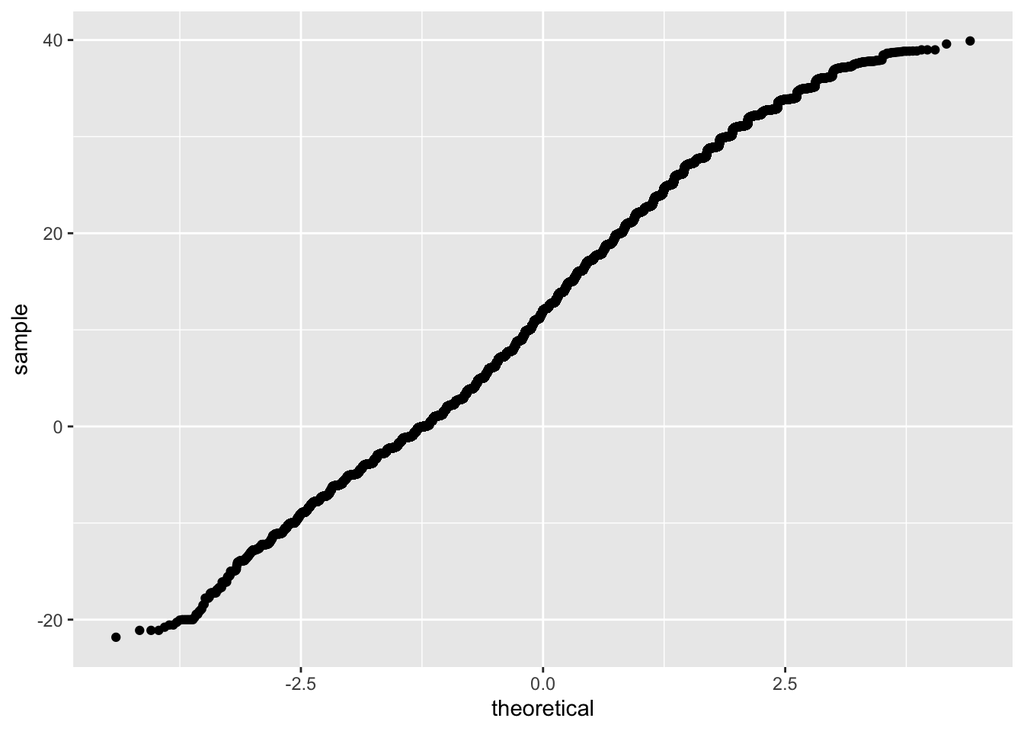

```r
ggplot(weatherHistory, aes(sample=temperature)) + stat_qq()
```

```r
ad.test(weatherHistory$temperature)
```

```
##
##  Anderson-Darling normality test
##
## data:  weatherHistory$temperature
## A = 202.38, p-value < 2.2e-16
```

```r
ad.test(weatherHistory$pressure)
```

```
##
##  Anderson-Darling normality test
##
## data:  weatherHistory$pressure
## A = 31503, p-value < 2.2e-16
```

We can also see that neither temperature or pressure follows a normal distribution.

### b) Explore the relationship between pressure and temperature.

To explore the relationship between pressure and temperature.

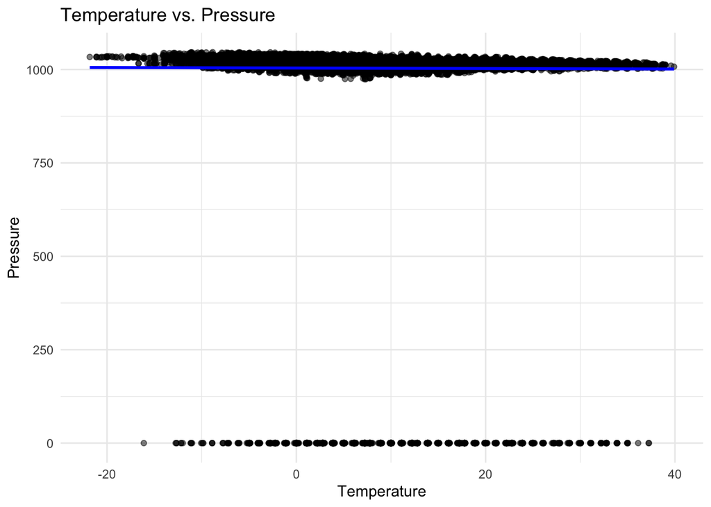

```r
ggplot(weatherHistory, aes(x = temperature, y = pressure)) +
  geom_point(alpha = 0.5) +  # using some transparency for points
  geom_smooth(method = "lm", se = FALSE, color = "blue", formula = y ~ x) +
  labs(title = "Temperature vs. Pressure",
       x = "Temperature",
       y = "Pressure") +
  theme_minimal()
```

It seems that the pressure outliers are affecting the relationship between temperature and pressure. Let’s remove them e see the correlation.

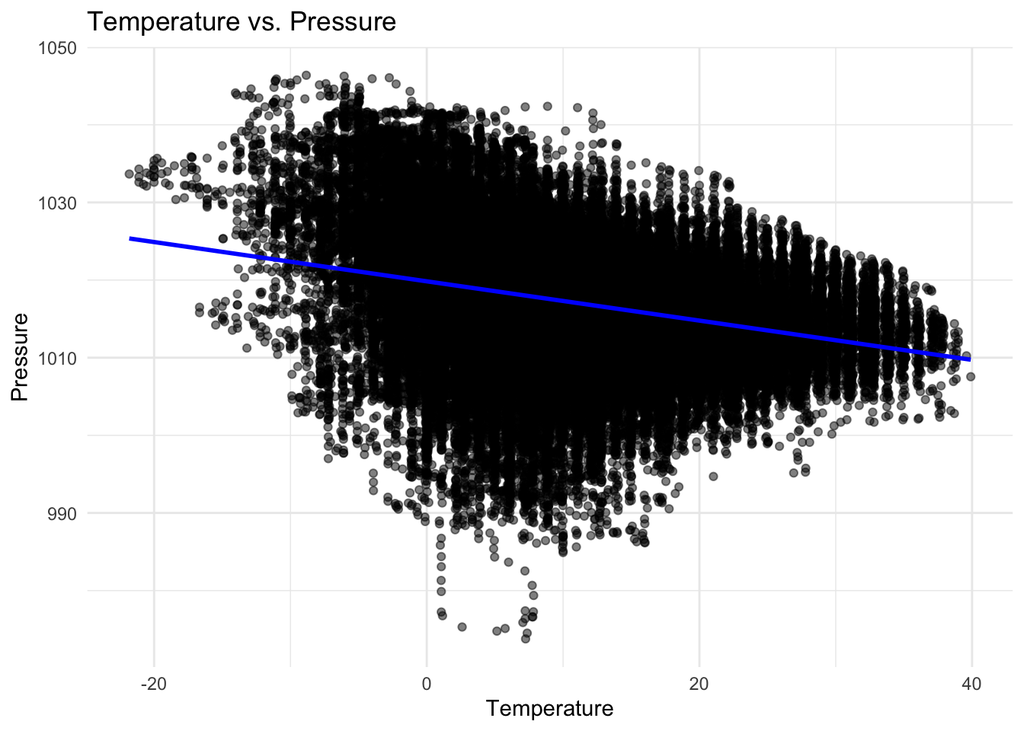

```r
weatherHistoryWithPressure <- weatherHistory %>%
    filter(pressure != 0) %>%
    filter(!is.na(temperature) & !is.na(pressure))


ggplot(weatherHistoryWithPressure, aes(x = temperature, y = pressure)) +
  geom_point(alpha = 0.5) +  # using some transparency for points
  geom_smooth(method = "lm", se = FALSE, color = "blue", formula = y ~ x) +
  labs(title = "Temperature vs. Pressure",
       x = "Temperature",
       y = "Pressure") +
  theme_minimal()
```

Let’s also do a Pearson’s correlation between the variables.

```r
cor.test(weatherHistoryWithPressure$temperature, weatherHistoryWithPressure$pressure)
```

```
##
##  Pearson's product-moment correlation
##
## data:  weatherHistoryWithPressure$temperature and weatherHistoryWithPressure$pressure
## t = -100.75, df = 95162, p-value < 2.2e-16
## alternative hypothesis: true correlation is not equal to 0
## 95 percent confidence interval:
##  -0.3161859 -0.3047036
## sample estimates:
##        cor
## -0.3104561
```

The scatterplot suggest that we have a non-linear relationship between temperature and pressure. So doing a linear regression model will not capture or explain the relationship between them.

The correlation coefficient from the Pearson’s test indicates a negative relationship of 0.31. So it means when the temperature increases the pressure decreases.

The p-value is also too low (2.2e-16) suggesting the relationship is statistical significant.

### c) Build a linear model considering temperature and pressure.

First let’s create the model.

```r
lmTemperaturePressure <-  lm(pressure ~ temperature,
                             data = weatherHistoryWithPressure)
anova(lmTemperaturePressure)
```

```
## Analysis of Variance Table
##
## Response: pressure
##                Df  Sum Sq Mean Sq F value    Pr(>F)
## temperature     1  554943  554943   10150 < 2.2e-16 ***
## Residuals   95162 5202744      55
## ---
## Signif. codes:  0 '***' 0.001 '**' 0.01 '*' 0.05 '.' 0.1 ' ' 1
```

```r
summary(lmTemperaturePressure)
```

```
##
## Call:
## lm(formula = pressure ~ temperature, data = weatherHistoryWithPressure)
##
## Residuals:
##     Min      1Q  Median      3Q     Max
## -44.223  -4.050   0.450   4.501  25.527
##
## Coefficients:
##               Estimate Std. Error t value Pr(>|t|)
## (Intercept)  1.020e+03  3.840e-02 26557.4   <2e-16 ***
## temperature -2.530e-01  2.511e-03  -100.7   <2e-16 ***
## ---
## Signif. codes:  0 '***' 0.001 '**' 0.01 '*' 0.05 '.' 0.1 ' ' 1
##
## Residual standard error: 7.394 on 95162 degrees of freedom
## Multiple R-squared:  0.09638,    Adjusted R-squared:  0.09637
## F-statistic: 1.015e+04 on 1 and 95162 DF,  p-value: < 2.2e-16
```

Standartize co-efficients to get the result expressed in standart deviations.

```r
lm.beta(lmTemperaturePressure)
```

```
##
## Call:
## lm(formula = pressure ~ temperature, data = weatherHistoryWithPressure)
##
## Standardized Coefficients::
## (Intercept) temperature
##          NA  -0.3104561
```

```r
suppressWarnings(stargazer(lmTemperaturePressure, type="text"))
```

```
##
## =================================================
##                          Dependent variable:
##                     -----------------------------
##                               pressure
## -------------------------------------------------
## temperature                   -0.253***
##                                (0.003)
##
## Constant                    1,019.837***
##                                (0.038)
##
## -------------------------------------------------
## Observations                   95,164
## R2                              0.096
## Adjusted R2                     0.096
## Residual Std. Error      7.394 (df = 95162)
## F Statistic         10,150.310*** (df = 1; 95162)
## =================================================
## Note:                 *p<0.1; **p<0.05; ***p<0.01
```

So we got the following results:

- For every 1 degree increase in temperature the pressure decreases 0.253 units.
- The p value is 0.01 who give us 99% confidence level. Also our F statistic is 10,150.310. Suggesting that the temperature is a good predictor of pressure.
- R squared is 0.096 meaning that 9.6% of the pressure variance is explained by the temperature.

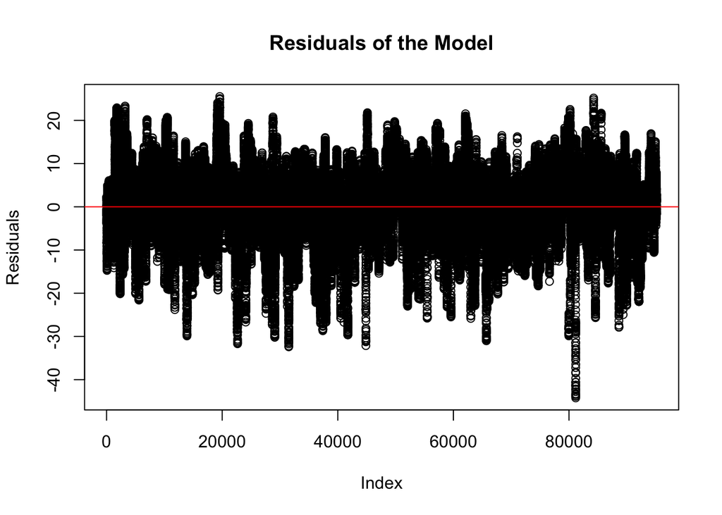

```r
plot(residuals(lmTemperaturePressure), main = "Residuals of the Model",
     xlab = "Index", ylab = "Residuals")
abline(h = 0, col = "red")
```

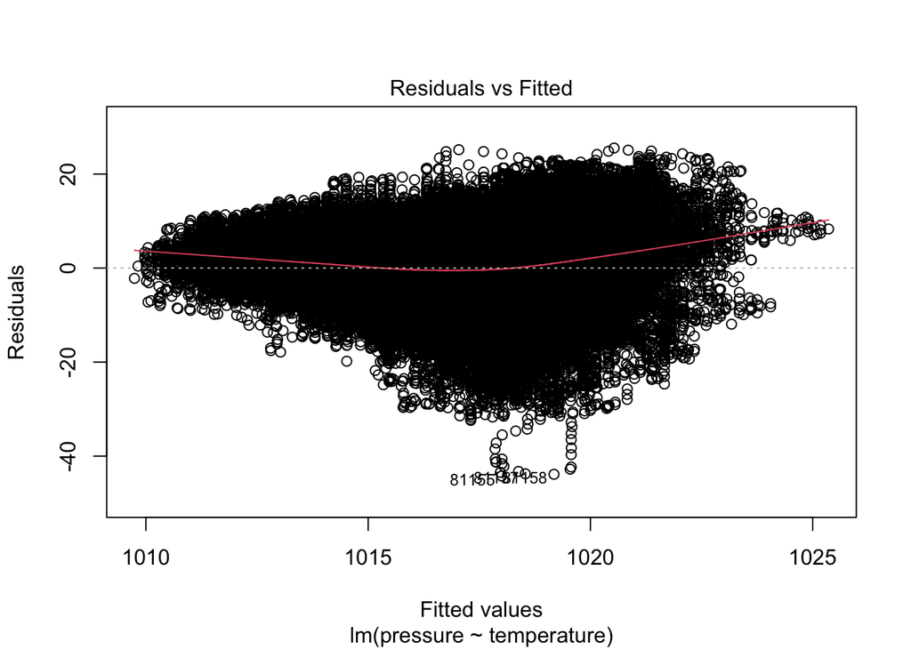

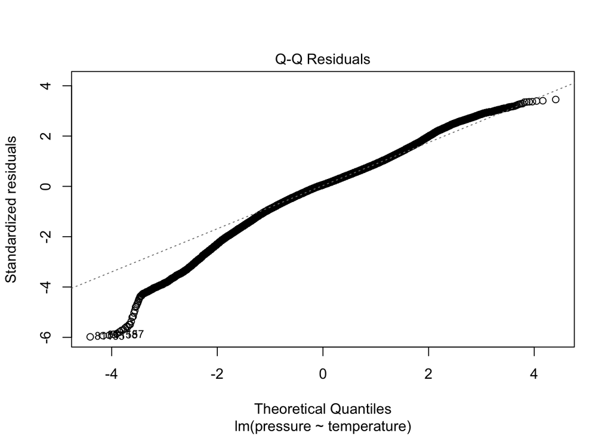

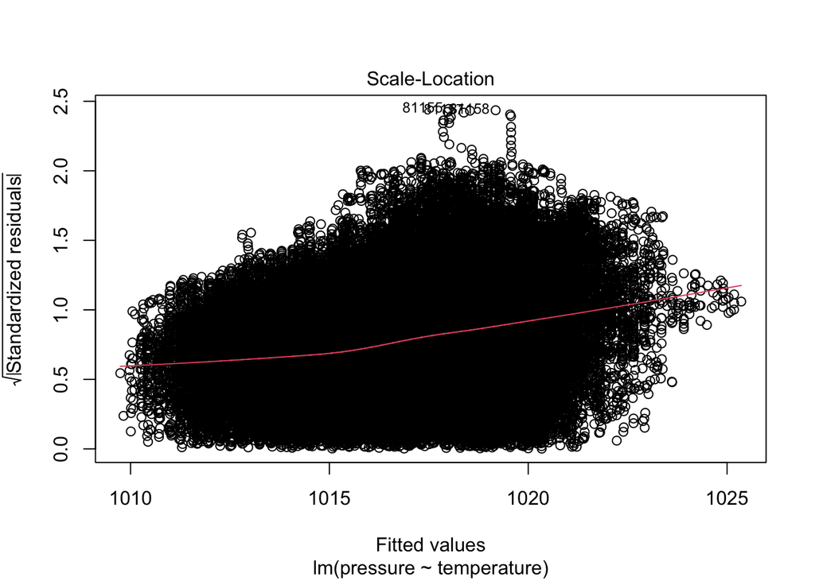

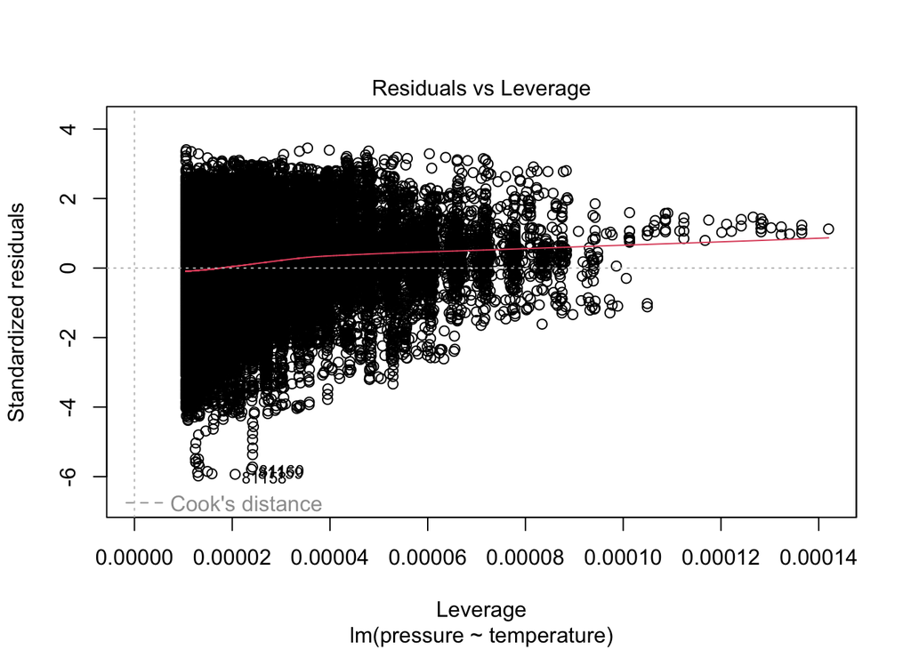

```r
plot(lmTemperaturePressure)
```

Looking at the residuals we can see that there is a funneling effect showing a spread out as the fitted values increase suggesting a non-constant variance.

#### d) Identify a dummy variable and build extended model considering dummy variable.

```r
weatherHistoryDummy <- weatherHistory
weatherHistoryDummy$humidityScale <- cut(weatherHistory$windSpeed,
                                     breaks=c(0, 0.25, 0.6, 1),
                                     labels=c("dry", "comfortable", "humid"))
levels(weatherHistoryDummy$humidityScale)
```

```
## [1] "dry"         "comfortable" "humid"
```

```r
table(weatherHistoryDummy$humidityScale)
```

```
##
##         dry comfortable       humid
##         293         453         268
```

Mapping them in our dataset.

```r
weatherHistoryDummy$dry <- ifelse(weatherHistoryDummy$humidityScale == "dry", 1, 0)
weatherHistoryDummy$comfortable <- ifelse(weatherHistoryDummy$humidityScale == "comfortable", 1, 0)
weatherHistoryDummy$humid <- ifelse(weatherHistoryDummy$humidityScale == "humid", 1, 0)

table(weatherHistoryDummy[, c("humidityScale")])
```

```
##
##         dry comfortable       humid
##         293         453         268
```

```r
table(weatherHistoryDummy[, c("dry")])
```

```
##
##   0   1
## 721 293
```

```r
table(weatherHistoryDummy[, c("comfortable")])
```

```
##
##   0   1
## 561 453
```

```r
table(weatherHistoryDummy[, c("humid")])
```

```
##
##   0   1
## 746 268
```

Lets consider the humid dummy variable and how it influenciates the pressure.

```r
lmTempPresWithDummy <- lm(pressure ~ temperature + humid, data = weatherHistoryDummy)
```

### e) Report your findings.

```r
summary(lmTempPresWithDummy)
```

```
##
## Call:
## lm(formula = pressure ~ temperature + humid, data = weatherHistoryDummy)
##
## Residuals:
##      Min       1Q   Median       3Q      Max
## -1015.12     3.20     8.10    14.09    33.55
##
## Coefficients:
##               Estimate Std. Error t value Pr(>|t|)
## (Intercept) 1010.01243    4.91890 205.333   <2e-16 ***
## temperature   -0.08503    0.30486  -0.279    0.780
## humid          6.05245    6.84406   0.884    0.377
## ---
## Signif. codes:  0 '***' 0.001 '**' 0.01 '*' 0.05 '.' 0.1 ' ' 1
##
## Residual standard error: 96.1 on 1011 degrees of freedom
##   (95438 observations deleted due to missingness)
## Multiple R-squared:  0.0008502,  Adjusted R-squared:  -0.001126
## F-statistic: 0.4302 on 2 and 1011 DF,  p-value: 0.6505
```

```r
lm.beta(lmTempPresWithDummy)
```

```
##
## Call:
## lm(formula = pressure ~ temperature + humid, data = weatherHistoryDummy)
##
## Standardized Coefficients::
##  (Intercept)  temperature        humid
##           NA -0.008768578  0.027800804
```

```r
suppressWarnings(stargazer(lmTempPresWithDummy, type="text"))
```

```
##
## ===============================================
##                         Dependent variable:
##                     ---------------------------
##                              pressure
## -----------------------------------------------
## temperature                   -0.085
##                               (0.305)
##
## humid                          6.052
##                               (6.844)
##
## Constant                   1,010.012***
##                               (4.919)
##
## -----------------------------------------------
## Observations                   1,014
## R2                             0.001
## Adjusted R2                   -0.001
## Residual Std. Error     96.102 (df = 1011)
## F Statistic            0.430 (df = 2; 1011)
## ===============================================
## Note:               *p<0.1; **p<0.05; ***p<0.01
```

Conclusions:

- The pressure is 1010.012 when the temperature and humidity is 0;
- The pressure drops 0.085 per degree increase in temperature;
- When the weather is humid the pressure increases 6.052;
- R-squared is less than 0.001 indicating that the model explain less than 1% of the variance to the pressure;
- A negative adjusted R-squared suggests that the model fits the data worse than just the mean of the dependent variable.
- F-statistic is 0.4302 with a p-value of 0.6505, indicating that the model is not statistically significant.